# Homework 6

Alan Vongsavanh

2026-01-26

## Instructions

Answer the following questions and/or complete the exercises in RMarkdown. Please embed all of your code and push the final work to your repository. Your report should be organized, clean, and run free from errors. Remember, you must remove the `#` for any included code chunks to run.

## Load the tidyverse

```r
library("tidyverse")
library("janitor")
```

## Data

For this assignment, we will use data from a study on vertebrate community composition and impacts from defaunation in [Gabon, Africa](https://en.wikipedia.org/wiki/Gabon). One thing to notice is that the data include 24 separate transects. Each transect represents a path through different forest management areas.

Reference: Koerner SE, Poulsen JR, Blanchard EJ, Okouyi J, Clark CJ. Vertebrate community composition and diversity declines along a defaunation gradient radiating from rural villages in Gabon. *Journal of Applied Ecology*. 2016. A description of the variables is included inside the data folder.

**1. Load `IvindoData_DryadVersion.csv` and store it as a new object called `gabon`.**

```r
gabon <- read.csv("data/IvindoData_DryadVersion.csv")
```

**2. Use one or more of the summary functions you have learned to get an idea of the structure of the data.**

```r
glimpse(gabon)
```

```
## Rows: 24
## Columns: 26
## $ TransectID              <int> 1, 2, 2, 3, 4, 5, 6, 7, 8, 9, 13, 14, 15, 16, …
## $ Distance                <dbl> 7.14, 17.31, 18.32, 20.85, 15.95, 17.47, 24.06…
## $ HuntCat                 <chr> "Moderate", "None", "None", "None", "None", "N…
## $ NumHouseholds           <int> 54, 54, 29, 29, 29, 29, 29, 54, 25, 73, 46, 56…
## $ LandUse                 <chr> "Park", "Park", "Park", "Logging", "Park", "Pa…
## $ Veg_Rich                <dbl> 16.67, 15.75, 16.88, 12.44, 17.13, 16.50, 14.7…
## $ Veg_Stems               <dbl> 31.20, 37.44, 32.33, 29.39, 36.00, 29.22, 31.2…
## $ Veg_liana               <dbl> 5.78, 13.25, 4.75, 9.78, 13.25, 12.88, 8.38, 8…
## $ Veg_DBH                 <dbl> 49.57, 34.59, 42.82, 36.62, 41.52, 44.07, 51.2…
## $ Veg_Canopy              <dbl> 3.78, 3.75, 3.43, 3.75, 3.88, 2.50, 4.00, 4.00…
## $ Veg_Understory          <dbl> 2.89, 3.88, 3.00, 2.75, 3.25, 3.00, 2.38, 2.71…
## $ RA_Apes                 <dbl> 1.87, 0.00, 4.49, 12.93, 0.00, 2.48, 3.78, 6.1…
## $ RA_Birds                <dbl> 52.66, 52.17, 37.44, 59.29, 52.62, 38.64, 42.6…
## $ RA_Elephant             <dbl> 0.00, 0.86, 1.33, 0.56, 1.00, 0.00, 1.11, 0.43…
## $ RA_Monkeys              <dbl> 38.59, 28.53, 41.82, 19.85, 41.34, 43.29, 46.2…
## $ RA_Rodent               <dbl> 4.22, 6.04, 1.06, 3.66, 2.52, 1.83, 3.10, 1.26…
## $ RA_Ungulate             <dbl> 2.66, 12.41, 13.86, 3.71, 2.53, 13.75, 3.10, 8…
## $ Rich_AllSpecies         <int> 22, 20, 22, 19, 20, 22, 23, 19, 19, 19, 21, 22…
## $ Evenness_AllSpecies     <dbl> 0.793, 0.773, 0.740, 0.681, 0.811, 0.786, 0.81…
## $ Diversity_AllSpecies    <dbl> 2.452, 2.314, 2.288, 2.006, 2.431, 2.429, 2.56…
## $ Rich_BirdSpecies        <int> 11, 10, 11, 8, 8, 10, 11, 11, 11, 9, 11, 11, 1…
## $ Evenness_BirdSpecies    <dbl> 0.732, 0.704, 0.688, 0.559, 0.799, 0.771, 0.80…
## $ Diversity_BirdSpecies   <dbl> 1.756, 1.620, 1.649, 1.162, 1.660, 1.775, 1.92…
## $ Rich_MammalSpecies      <int> 11, 10, 11, 11, 12, 12, 12, 8, 8, 10, 10, 11, …
## $ Evenness_MammalSpecies  <dbl> 0.736, 0.705, 0.650, 0.619, 0.736, 0.694, 0.77…
## $ Diversity_MammalSpecies <dbl> 1.764, 1.624, 1.558, 1.484, 1.829, 1.725, 1.92…
```

```r
summary(gabon)
```

```
##    TransectID       Distance        HuntCat          NumHouseholds
##  Min.   : 1.00   Min.   : 2.700   Length:24          Min.   :13.00
##  1st Qu.: 5.75   1st Qu.: 5.668   Class :character   1st Qu.:24.75
##  Median :14.50   Median : 9.720   Mode  :character   Median :29.00
##  Mean   :13.50   Mean   :11.879                      Mean   :37.88
##  3rd Qu.:20.25   3rd Qu.:17.683                      3rd Qu.:54.00
##  Max.   :27.00   Max.   :26.760                      Max.   :73.00
##    LandUse             Veg_Rich       Veg_Stems       Veg_liana
##  Length:24          Min.   :10.88   Min.   :23.44   Min.   : 4.750
##  Class :character   1st Qu.:13.10   1st Qu.:28.69   1st Qu.: 9.033
##  Mode  :character   Median :14.94   Median :32.45   Median :11.940
##                     Mean   :14.83   Mean   :32.80   Mean   :11.040
##                     3rd Qu.:16.54   3rd Qu.:37.08   3rd Qu.:13.250
##                     Max.   :18.75   Max.   :47.56   Max.   :16.380
##     Veg_DBH        Veg_Canopy    Veg_Understory     RA_Apes
##  Min.   :28.45   Min.   :2.500   Min.   :2.380   Min.   : 0.000
##  1st Qu.:40.65   1st Qu.:3.250   1st Qu.:2.875   1st Qu.: 0.000
##  Median :43.90   Median :3.430   Median :3.000   Median : 0.485
##  Mean   :46.09   Mean   :3.469   Mean   :3.020   Mean   : 2.045
##  3rd Qu.:50.58   3rd Qu.:3.750   3rd Qu.:3.167   3rd Qu.: 3.815
##  Max.   :76.48   Max.   :4.000   Max.   :3.880   Max.   :12.930
##     RA_Birds      RA_Elephant       RA_Monkeys      RA_Rodent
##  Min.   :31.56   Min.   :0.0000   Min.   : 5.84   Min.   :1.060
##  1st Qu.:52.51   1st Qu.:0.0000   1st Qu.:22.70   1st Qu.:2.047
##  Median :57.90   Median :0.3600   Median :31.74   Median :3.230
##  Mean   :58.64   Mean   :0.5450   Mean   :31.30   Mean   :3.278
##  3rd Qu.:68.17   3rd Qu.:0.8925   3rd Qu.:39.88   3rd Qu.:4.093
##  Max.   :85.03   Max.   :2.3000   Max.   :54.12   Max.   :6.310
##   RA_Ungulate     Rich_AllSpecies Evenness_AllSpecies Diversity_AllSpecies
##  Min.   : 0.000   Min.   :15.00   Min.   :0.6680      Min.   :1.966
##  1st Qu.: 1.232   1st Qu.:19.00   1st Qu.:0.7542      1st Qu.:2.248
##  Median : 2.545   Median :20.00   Median :0.7760      Median :2.317
##  Mean   : 4.166   Mean   :20.21   Mean   :0.7699      Mean   :2.310
##  3rd Qu.: 5.157   3rd Qu.:22.00   3rd Qu.:0.8083      3rd Qu.:2.429
##  Max.   :13.860   Max.   :24.00   Max.   :0.8330      Max.   :2.566
##  Rich_BirdSpecies Evenness_BirdSpecies Diversity_BirdSpecies Rich_MammalSpecies
##  Min.   : 8.00    Min.   :0.5590       Min.   :1.162         Min.   : 6.000
##  1st Qu.:10.00    1st Qu.:0.6825       1st Qu.:1.603         1st Qu.: 9.000
##  Median :11.00    Median :0.7220       Median :1.680         Median :10.000
##  Mean   :10.33    Mean   :0.7137       Mean   :1.661         Mean   : 9.875
##  3rd Qu.:11.00    3rd Qu.:0.7722       3rd Qu.:1.784         3rd Qu.:11.000
##  Max.   :13.00    Max.   :0.8240       Max.   :2.008         Max.   :12.000
##  Evenness_MammalSpecies Diversity_MammalSpecies
##  Min.   :0.6190         Min.   :1.378
##  1st Qu.:0.7073         1st Qu.:1.567
##  Median :0.7390         Median :1.699
##  Mean   :0.7477         Mean   :1.698
##  3rd Qu.:0.7847         3rd Qu.:1.815
##  Max.   :0.8610         Max.   :2.065
```

**3. Clean the data as necessary following the conventions from lab 6.**

```r
gabon <- gabon %>%
  clean_names() %>%
  mutate(across(where(is.character),tolower))
```

**4. Use `mutate()` Change the variables `HuntCat`, `LandUse`, and `TransectID` to factors. Be sure to store the output as a new dataframe and use it for the remaining questions.**

```r
gabon <- gabon %>%
  mutate(across(c(hunt_cat, land_use, transect_id), as.factor))
```

**5. Make a plot that shows the number of transects for each land use type.**

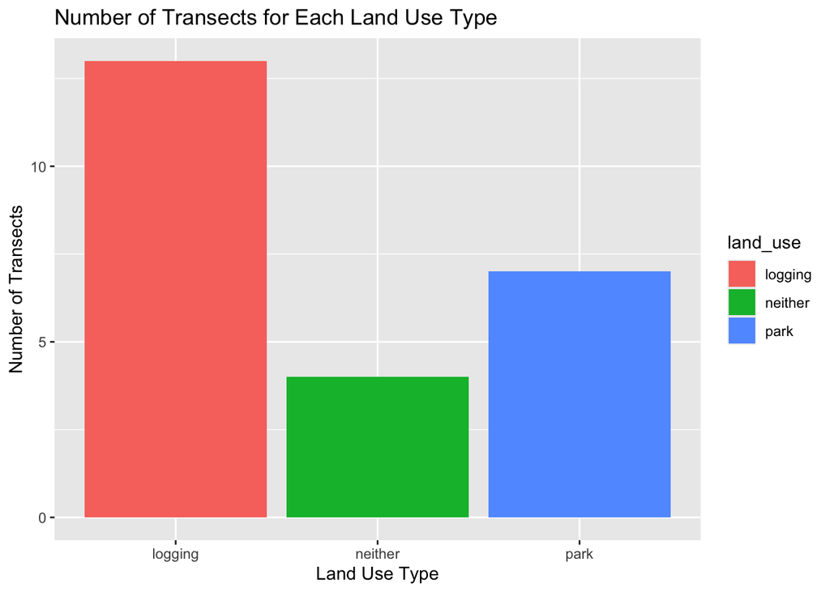

```r
gabon %>%
  ggplot(mapping = aes(x = land_use)) +
    geom_bar(mapping = aes(fill = land_use)) +
    labs(title = "Number of Transects for Each Land Use Type",
      x = "Land Use Type",
      y = "Number of Transects")
```

**6. How does vegetation richness compare among land use types?**

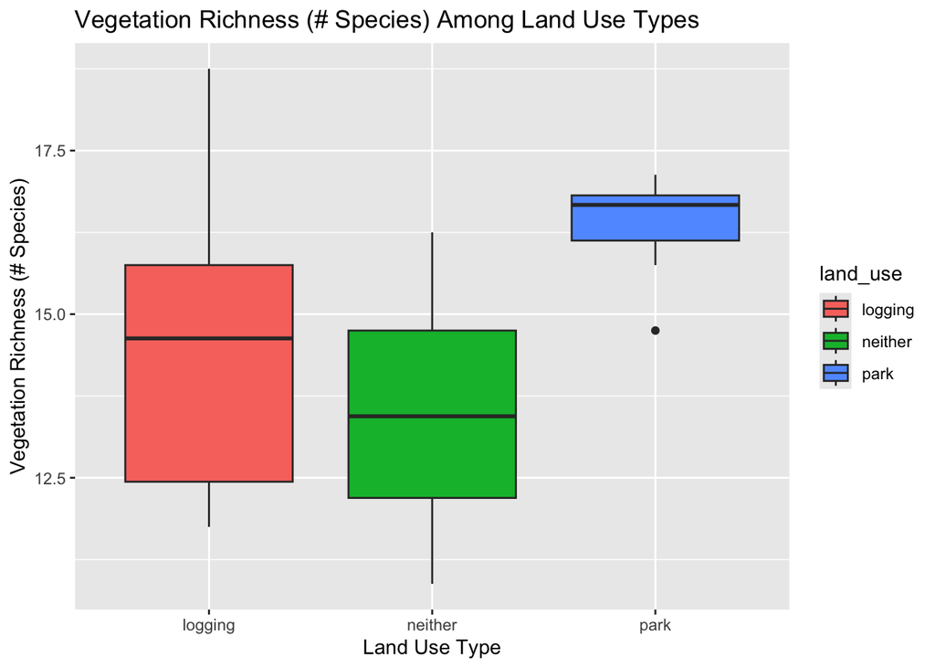

```r
gabon %>%
  ggplot(mapping = aes(x = land_use, y = veg_rich)) +
    geom_boxplot(mapping = aes(fill = land_use)) +
    labs(title = "Vegetation Richness (# Species) Among Land Use Types",
      x = "Land Use Type",
      y = "Vegetation Richness (# Species)")
```

**7. For which land use type (national parks, logging, or neither) is average all species diversity the greatest?**

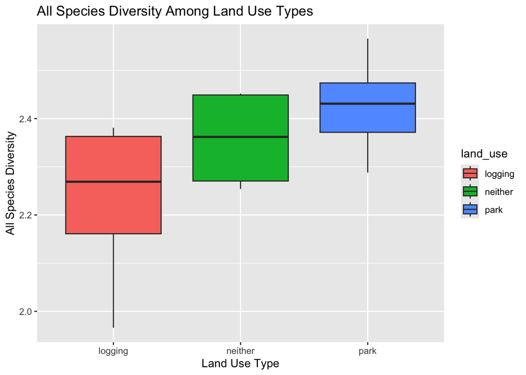

```r
gabon %>%
  ggplot(mapping = aes(x = land_use, y = diversity_all_species)) +
    geom_boxplot(mapping = aes(fill = land_use)) +
    labs(title = "All Species Diversity Among Land Use Types",
      x = "Land Use Type",
      y = "All Species Diversity")
```

**8. Is there a relationship between vegetation richness and mammal species richness?**

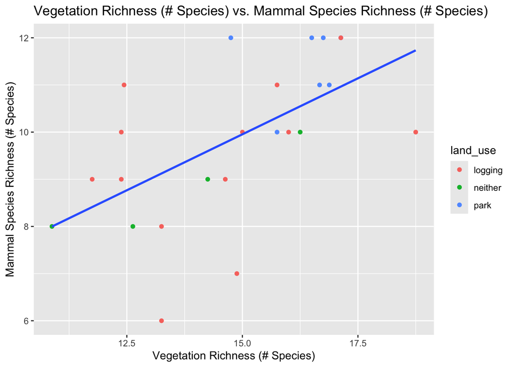

```r
gabon %>%
  ggplot(mapping = aes(x = veg_rich, y = rich_mammal_species)) +
    geom_point(mapping = aes(color = land_use)) +
    geom_smooth(method = lm, se = F, na.rm = T) +
    labs(title = "Vegetation Richness (# Species) vs. Mammal Species Richness (# Species)",
      x = "Vegetation Richness (# Species)",
      y = "Mammal Species Richness (# Species)")
```

**9. Use `filter` to find all transects that have greater than 15 tree species or a breast height diameter between 50 and 60cm.**

```r
gabon %>%
  select(transect_id, land_use, veg_rich, veg_dbh) %>%
  filter(veg_rich >= 15 | between(veg_dbh, 50, 60)) %>%
  arrange(desc(veg_dbh))
```

```
##    transect_id land_use veg_rich veg_dbh
## 1           25  logging    15.00   76.48
## 2            9  logging    16.00   69.30
## 3           17  neither    14.25   57.71
## 4           15  neither    10.88   54.77
## 5           14  logging    15.75   52.12
## 6            6     park    14.75   51.22
## 7           21  neither    16.25   50.36
## 8            1     park    16.67   49.57
## 9           24     park    16.75   44.21
## 10           5     park    16.50   44.07
## 11           2     park    16.88   42.82
## 12           4     park    17.13   41.52
## 13          22  logging    17.13   39.31
## 14          26  logging    18.75   35.58
## 15           2     park    15.75   34.59
```

**10.Which transects and land use types have more than 10 tree species and 10 mammal species? Use `arrange()` to sort by the number of tree species.**

```r
gabon %>%
  select(transect_id, land_use, veg_rich, rich_mammal_species) %>%
  filter(veg_rich >= 10 & rich_mammal_species >= 10) %>%
  arrange(desc(veg_rich))
```

```
##    transect_id land_use veg_rich rich_mammal_species
## 1           26  logging    18.75                  10
## 2            4     park    17.13                  12
## 3           22  logging    17.13                  12
## 4            2     park    16.88                  11
## 5           24     park    16.75                  12
## 6            1     park    16.67                  11
## 7            5     park    16.50                  12
## 8           21  neither    16.25                  10
## 9            9  logging    16.00                  10
## 10           2     park    15.75                  10
## 11          14  logging    15.75                  11
## 12          25  logging    15.00                  10
## 13           6     park    14.75                  12
## 14           3  logging    12.44                  11
## 15          13  logging    12.38                  10
```

## Knit and Upload

Please knit your work as an .html file and upload to Canvas. Homework is due before the start of the next lab. No late work is accepted. Make sure to use the formatting conventions of RMarkdown to make your report neat and clean!